# テスト

Kohei Hamabe

2021/5/20

# はじめに…

- 2018年までのマサバ太平洋系群データを使ってVPA計算とモデル診断を模擬的に行います
- 資源管理研修用に少し調整したデータとなっています
- **本研修はフィクションで、実際の資源評価とは関係ありません**

# 0. 準備

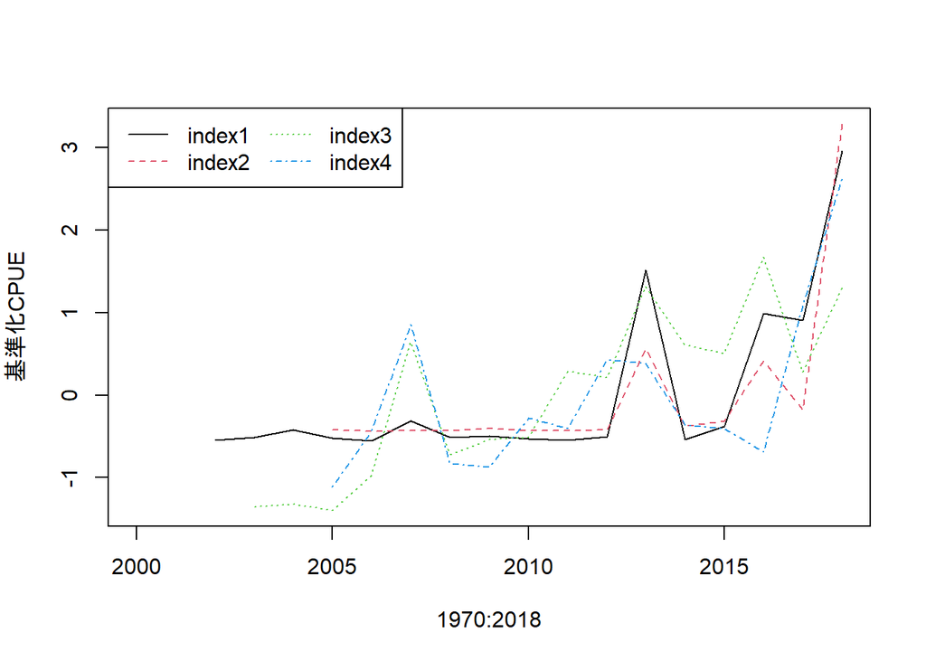

```r
caa  <- read.csv("data/caa0_2020.csv", row.names = 1)[,-(50:51)]
waa  <- read.csv("data/waa1_2020.csv", row.names = 1)[,-(50:51)]
maa  <- read.csv("data/maa2_2020.csv", row.names = 1)[,-(50:51)]
cpue <- read.csv("data/cpue2_aicc2020.csv", row.names = 1)[,-(50:51)]
dat  <- data.handler(caa, waa, maa, cpue, M=0.4)
dat$index[1:2,"2018"] <- NA
dat$caa[,"2018"] <- rep(0, nrow(dat$caa))

# 資源量指数のプロット
cpue2 <- cpue
cpue2[1,] <- (cpue[1,]-mean(as.numeric(cpue[1,]), na.rm=TRUE))/
  sd(as.numeric(cpue[1,]), na.rm=TRUE)
cpue2[2,] <- (cpue[2,]-mean(as.numeric(cpue[2,]), na.rm=TRUE))/
  sd(as.numeric(cpue[2,]), na.rm=TRUE)
cpue2[3,] <- (cpue[3,]-mean(as.numeric(cpue[3,]), na.rm=TRUE))/
  sd(as.numeric(cpue[3,]), na.rm=TRUE)
cpue2[4,] <- (cpue[4,]-mean(as.numeric(cpue[4,]), na.rm=TRUE))/
  sd(as.numeric(cpue[4,]), na.rm=TRUE)
matplot(1970:2018,t(cpue2), type = "l", xlim = c(2000,2018),
        ylab = "基準化CPUE")
legend("topleft", legend = c("index1","index2","index3","index4"),
       col = 1:4, lty=1:4, ncol=2)
```

# 1. チューニング無VPA

- VPAは年齢別漁獲尾数データから資源量計算が可能な便利なツールです
- まずは年齢別漁獲尾数データだけで資源計算をしていきたいと思います

```r
res1.1 <- vpa(dat=dat,
              tf.year = 2015:2017,
              plus.group = TRUE,
              Pope = TRUE,
              tune = FALSE,
              p.init = 0.5
              )
res1.1$faa[,as.character(2013:2017)]
```

```
##         2013       2014       2015      2016 2017
## 0 0.02528343 0.06180418 0.04091019 0.3926173  Inf
## 1 0.23473894 0.11049708 0.12867685 0.3056949  Inf
## 2 0.28376790 0.30533974 0.35776323 0.3174360  Inf
## 3 0.64226932 0.54832754 0.53334540 0.7444189  Inf
## 4 0.28209991 0.35898387 0.31553981 0.3061173  Inf
## 5 1.19558458 0.44157478 0.53660482 0.7312367  Inf
## 6 1.19558458 0.44157478 0.53660482 0.7312367  Inf
```

```r
# 最終年のFの平均年数を変えてみる
res1.2 <- vpa(dat=dat,
              tf.year = 2013:2017,
              plus.group = TRUE,
              Pope = TRUE,
              tune = FALSE,
              p.init = 0.5
              )
res1.2$faa[,as.character(2013:2017)]
```

```
##         2013       2014       2015      2016 2017
## 0 0.02528343 0.06180418 0.04091019 0.3926173  Inf
## 1 0.23473894 0.11049708 0.12867685 0.3056949  Inf
## 2 0.28376790 0.30533974 0.35776323 0.3174360  Inf
## 3 0.64226932 0.54832754 0.53334540 0.7444189  Inf
## 4 0.28209991 0.35898387 0.31553981 0.3061173  Inf
## 5 1.19558458 0.44157478 0.53660482 0.7312367  Inf
## 6 1.19558458 0.44157478 0.53660482 0.7312367  Inf
```

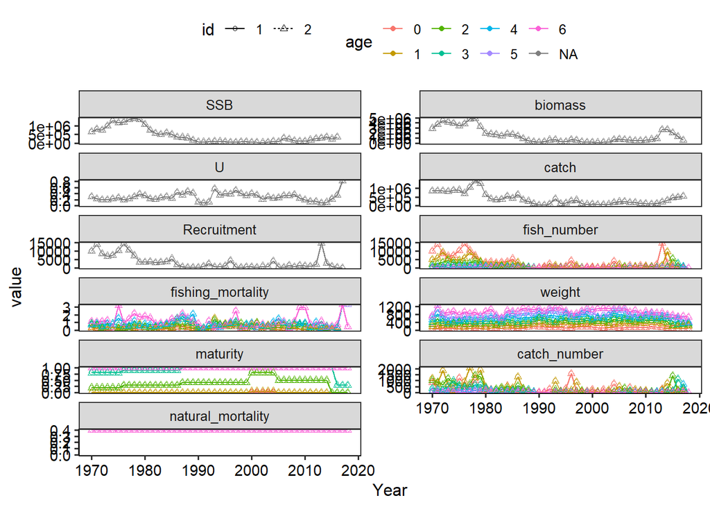

```r
# プロットをしてみる
plot_vpa(list(res1.1, res1.2))
```

**まずは最近年のFが推定できているかチェック**

- 最終年のFの推定が収束していない
- 漁獲量データから資源動態を推定するのは難しい…
- ならば最近年の情報を足して、もう少しデータに基づいた資源評価をしてみよう
- ちょうどいいところに**CPUE**があるぞ!

# 2. チューニングVPA

- VPAは最近年の推定値の不確実性が大きいという特性を持っています
- そこで、資源量指標値のトレンドにフィットさせることで、更に情報の持った資源量推定ができます
- これをチューニングVPAといい、チューニングVPAには最適化手法や推定するFの対象に応じて様々な仕様があります

## 1．最小二乗法推定

- 今、４つの資源量指標値があります
- それぞれの資源量指標値の重み（信頼度のようなもの）を等しいとして計算します

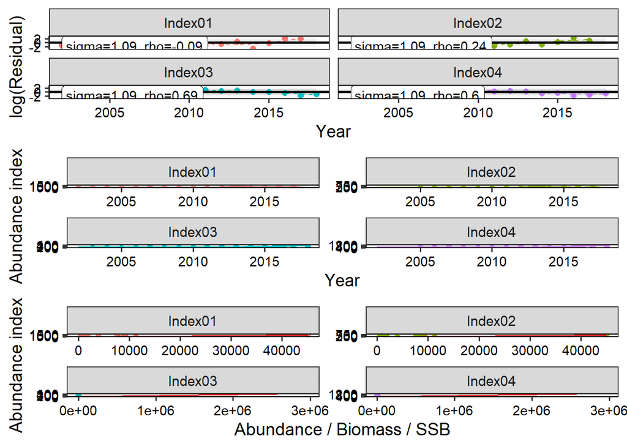

```r
res2.1 <- vpa(dat=dat,
              tf.year = 2015:2017,
              plus.group = TRUE,
              last.catch.zero = TRUE,
              Pope = TRUE,
              tune = TRUE, #チューニングをする場合はTRUE
              alpha = 1, #最高齢のFと(最高齢-1)歳のFの比
              sel.update = TRUE,
                         #選択率更新法(最終年最高齢をターミナルFにする場合はTRUEに)
              est.method = "ls", #最適化手法は最小二乗法
              term.F = "max", #推定する最終年のFは最高齢のFを一つ推定
              abund = c("N","N","SSB","SSB"), #資源量指標値が何に対応しているか
              min.age = c(0,0,0,0), #資源量指標値が対応している年齢の下限
              max.age = c(0,0,6,6), #資源量指標値が対応している年齢の上限
              use.index = 1:4, #どの資源量指標値を使うか
              plot = TRUE,
              plot.year = 2002:2018
              )
```

```r
res2.1$faa[,as.character(2013:2017)]
```

```
##          2013       2014        2015       2016       2017
## 0 0.008065303 0.01524298 0.004641667 0.01613209 0.01228393
## 1 0.125696604 0.03364325 0.029520889 0.02978417 0.03440618
## 2 0.184260087 0.14295076 0.092203665 0.06117555 0.08833886
## 3 0.446079125 0.30146472 0.195882351 0.12543881 0.18495444
## 4 0.190327469 0.20854436 0.139675416 0.08444706 0.12888234
## 5 0.909479347 0.26088313 0.252274461 0.23518186 0.28240884
## 6 0.909479347 0.26088313 0.252274461 0.23518186 0.28240884
```

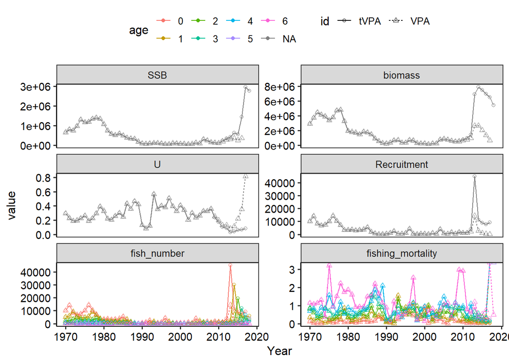

```r
# プロットをしてみる
plot_vpa(list(VPA = res1.1, tVPA = res2.1),
         what.plot = c("SSB", "biomass", "U", "Recruitment",
                       "fish_number", "fishing_mortality"))
```

### モデル診断1: 残差プロット

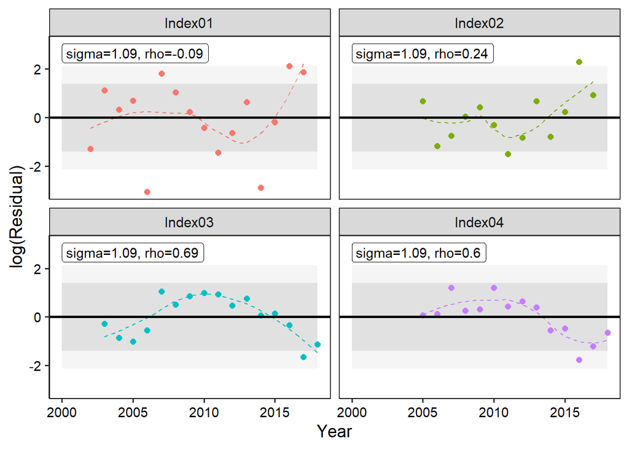

```r
resid2.1 <- plot_residual_vpa(res2.1, plot_year = 2000:2018)
resid2.1$year_resid
```

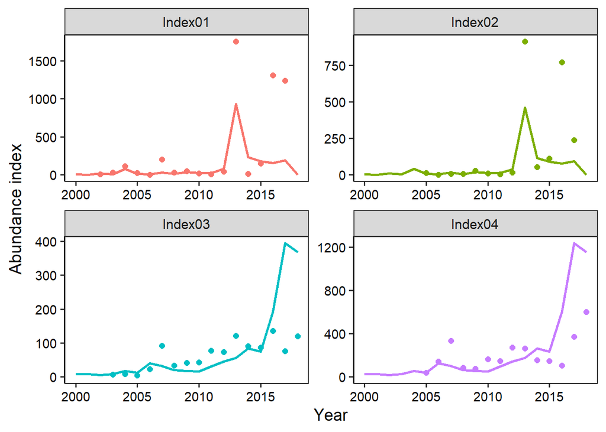

```r
resid2.1$fitting_Index
```

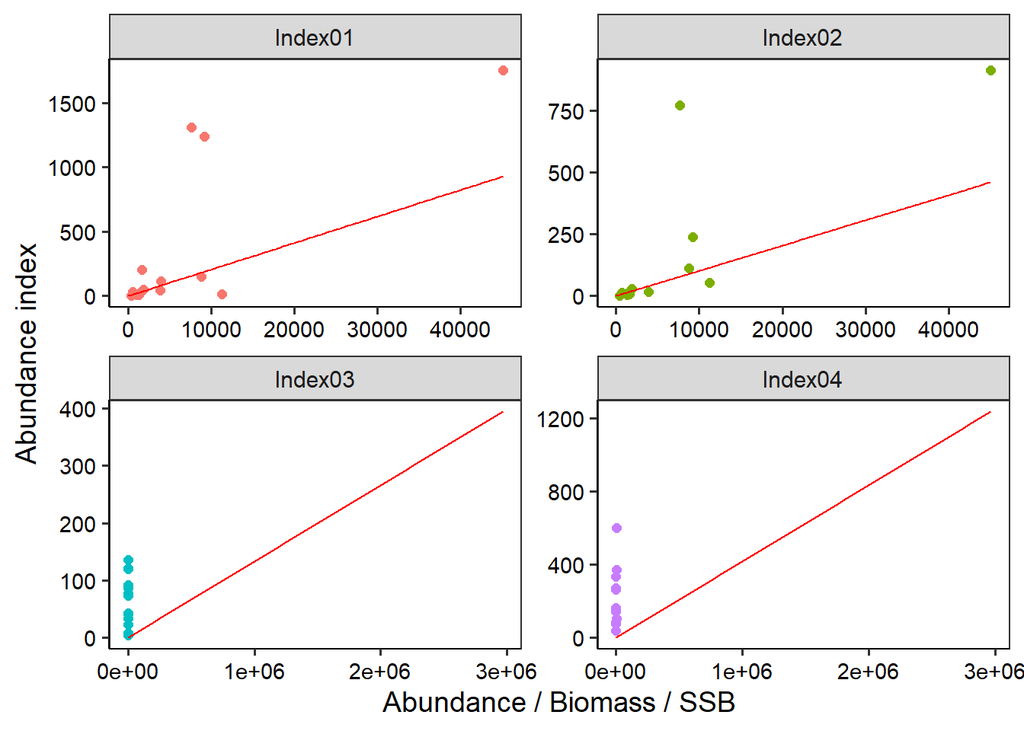

```r
resid2.1$abund_Index
```

### モデル診断2: レトロスペクティブ解析

```r
retro2.1 <- do_retrospective_vpa(res2.1)
```

```
## * value -> value...1
## * value -> value...2
## * value -> value...3
## * value -> value...4
## * value -> value...5
```

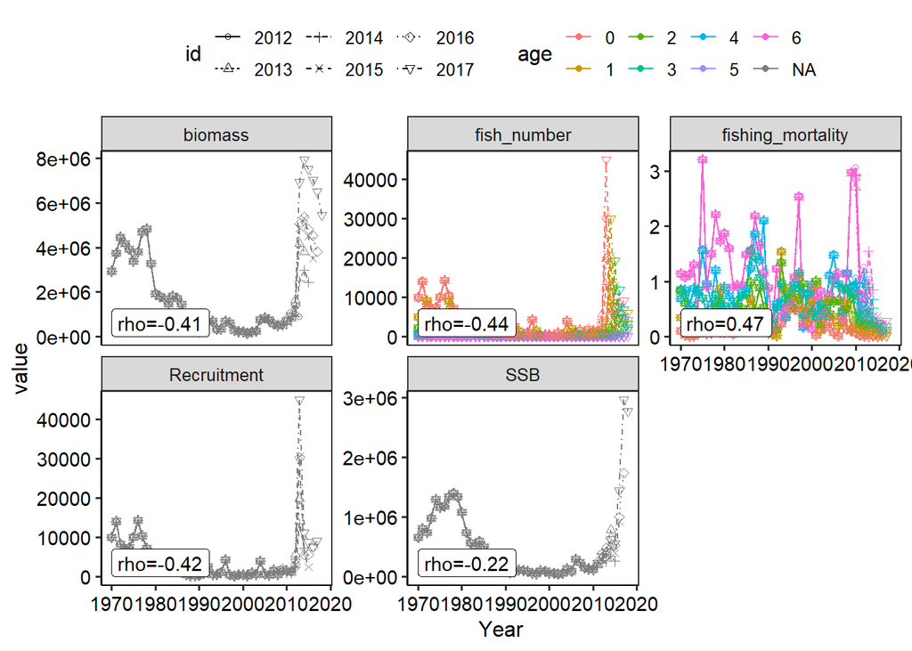

```r
retro2.1$graph
```

- 資源量指標値の情報を加えることで、先程までと異なりFの推定が安定したように見えます
- ただし、最近SSBが本当に増えているのでしょうか?
- 確認するにはいろんな方法がありますが、まずは自分でできること、データの扱い方でもう少し検討していきたいと思います

## 2．最尤推定法

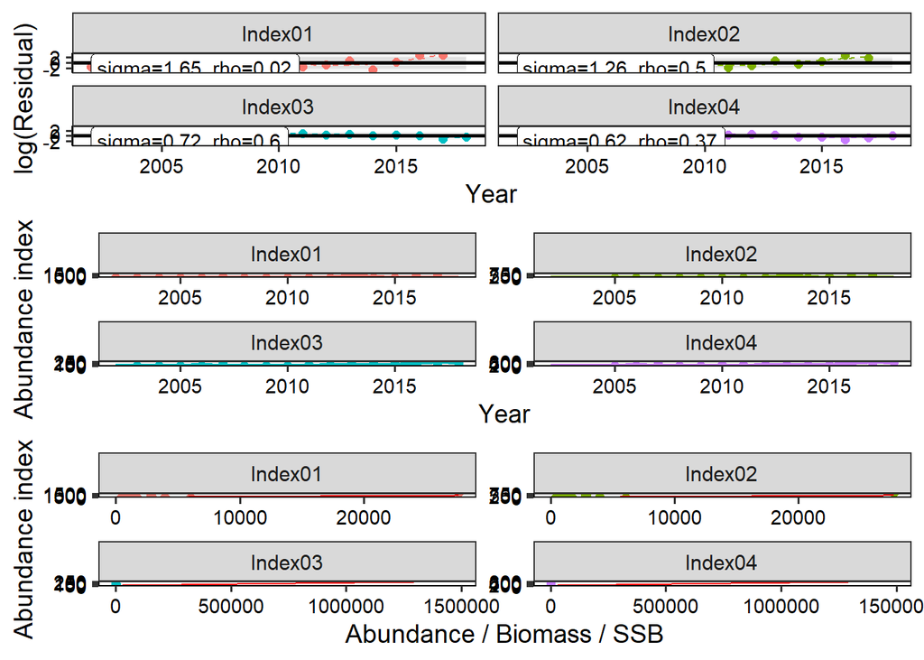

```r
res3.1 <- vpa(dat=dat,
              tf.year = 2015:2017,
              plus.group = TRUE,
              last.catch.zero = TRUE,
              Pope = TRUE,
              tune = TRUE,
              alpha = 1,
              sel.update = TRUE,
              est.method = "ml", #最適化手法を最尤推定法に
              term.F = "max",
              abund = c("N","N","SSB","SSB"),
              min.age = c(0,0,0,0),
              max.age = c(0,0,6,6),
              use.index = 1:4,
              sigma.constraint = c(1,2,3,4),
              plot = TRUE,
              plot.year = 2002:2018
              )
```

```r
# まずは年齢別漁獲尾数
res3.1$faa[,as.character(2013:2017)]
```

```
##         2013       2014       2015       2016       2017
## 0 0.01317437 0.02857843 0.01037745 0.04317906 0.04070677
## 1 0.17323769 0.05570229 0.05646951 0.06806017 0.09625089
## 2 0.23239705 0.20839162 0.15953784 0.12224005 0.21936160
## 3 0.54394633 0.41028168 0.31226090 0.23713621 0.42776024
## 4 0.23560338 0.27709160 0.20817945 0.14753008 0.27725227
## 5 1.05756815 0.34389421 0.36674240 0.39091665 0.58675237
## 6 1.05756815 0.34389421 0.36674240 0.39091665 0.58675237
```

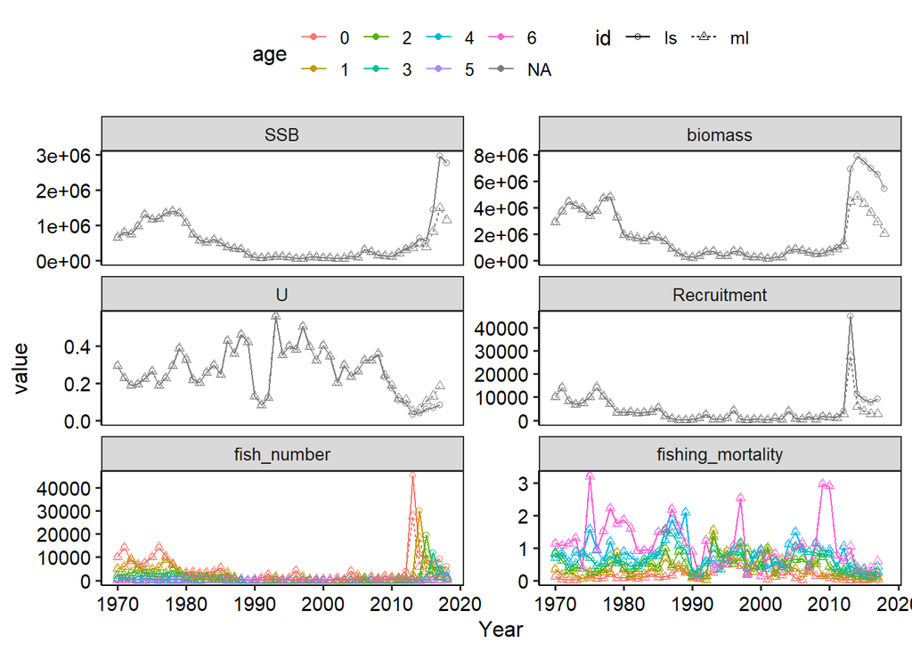

```r
# 資源動態の比較
plot_vpa(list(ls = res2.1, ml = res3.1),
         what.plot = c("SSB", "biomass", "U", "Recruitment",
                       "fish_number", "fishing_mortality"))
```

```r
# 観測誤差（各データの重み）を見る
res3.1$sigma
```

```
## [1] 1.6461260 1.2569130 0.7207365 0.6209931
```

### モデル診断1: 残差プロット

- 残差プロットを比較してみよう

**patchworkパッケージが必要です!!**

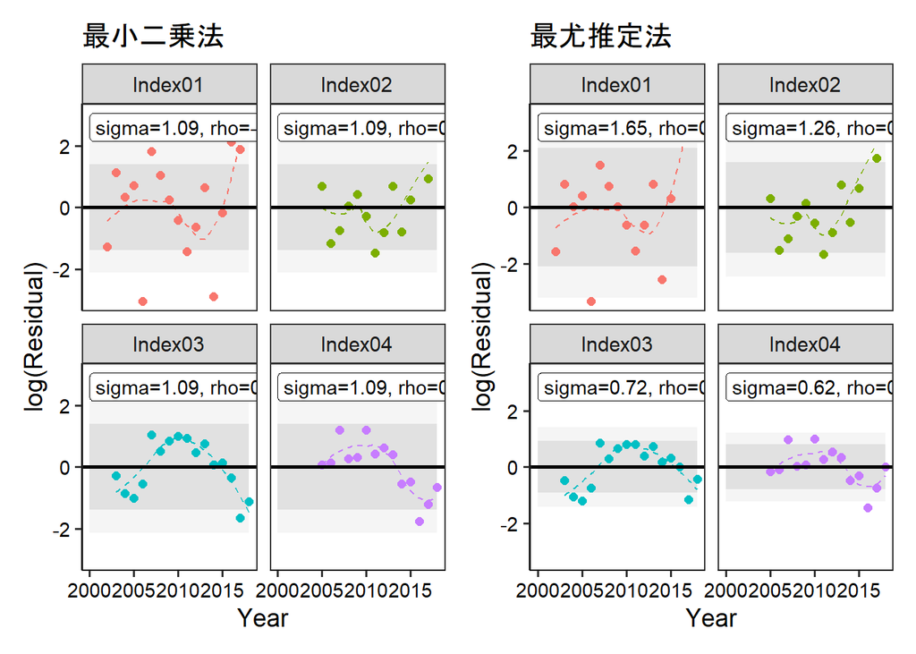

```r
resid3.1 <- plot_residual_vpa(res3.1, plot_year = 2000:2018)

# 残差の時系列プロット
resid2.1$year_resid+ggtitle("最小二乗法") | resid3.1$year_resid+ggtitle("最尤推定法")
```

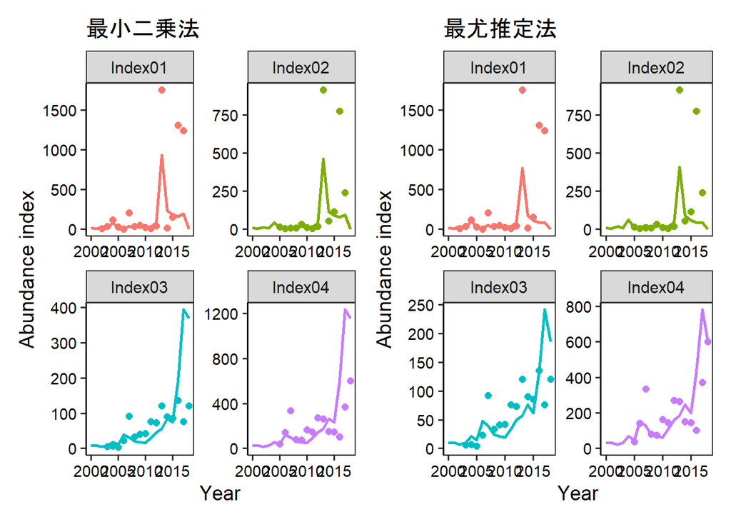

```r
# 資源量とのフィッティング
resid2.1$fitting_Index+ggtitle("最小二乗法") | resid3.1$fitting_Index+ggtitle("最尤推定法")
```

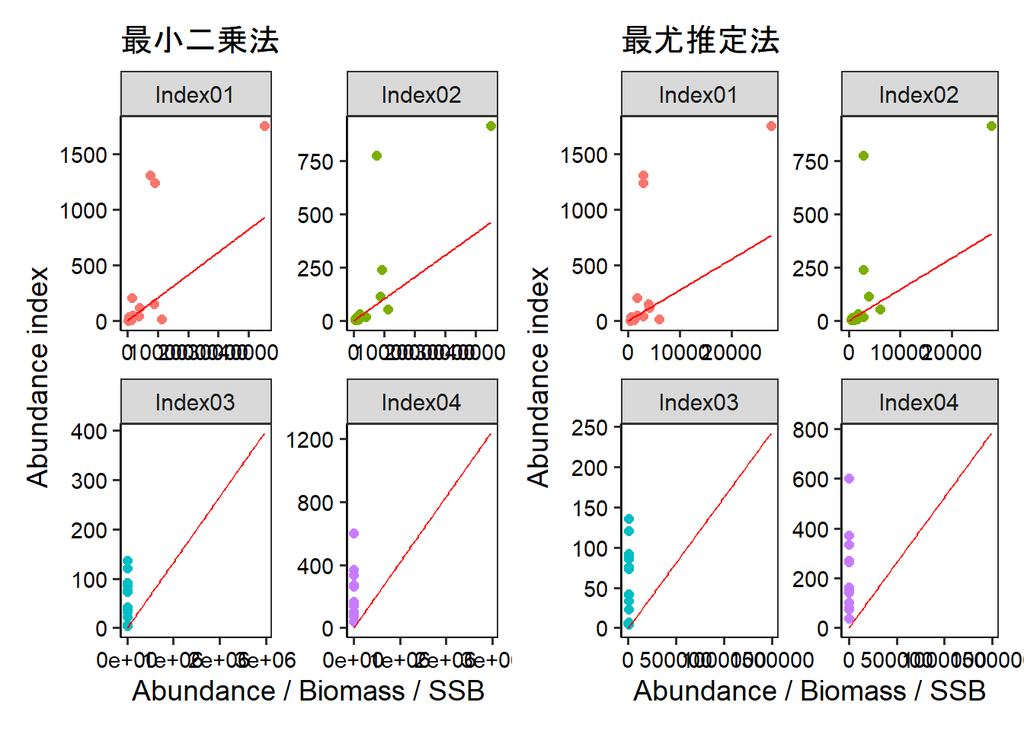

```r
# 資源量と指数の線形関係
resid2.1$abund_Index+ggtitle("最小二乗法") |resid3.1$abund_Index+ggtitle("最尤推定法")
```

### モデル診断2: レトロスペクティブ解析

```r
retro3.1 <- do_retrospective_vpa(res3.1)
```

```
## * value -> value...1
## * value -> value...2
## * value -> value...3
## * value -> value...4
## * value -> value...5
```

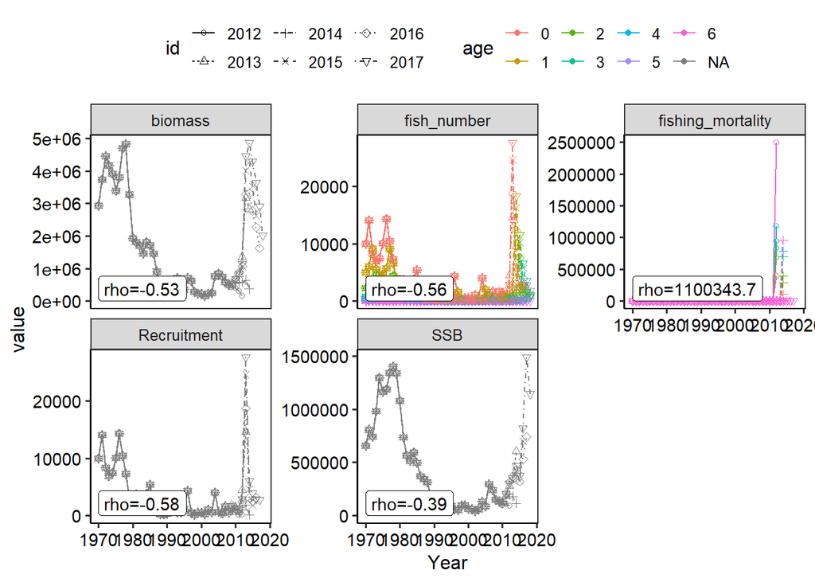

```r
retro3.1$graph
```

- Mohn’s rhoが大きくなっちゃった
- これは最尤法はデータごとに重み付けを出来る反面、データにオーバーフィットする傾向があることが要因の一つであると言える
- 2012年までは加入の指数は軒並み横ばいだったけど、SSBの指数は2008年頃から増加傾向にありました -このデータトレンドを説明するためにFを大きくしてモデルをフィットさせてしまったと考えられます
- 最小二乗法では加入と親魚の指数の重みを等しくしていたので、SSBの指数の傾向にフィットしすぎるということが見られず、結果としてレトロスペクティブ解析が安定しているといえます

### 重みを少しまとめた解析

- 加入の指数の観測誤差は1.2以上と大きめでした
- 一方、親魚の指数は0.65程と加入指数に比べて小さめでした
- それぞれの指数の重みを出しましたが、加入か親魚かで2分しても推定が可能では？

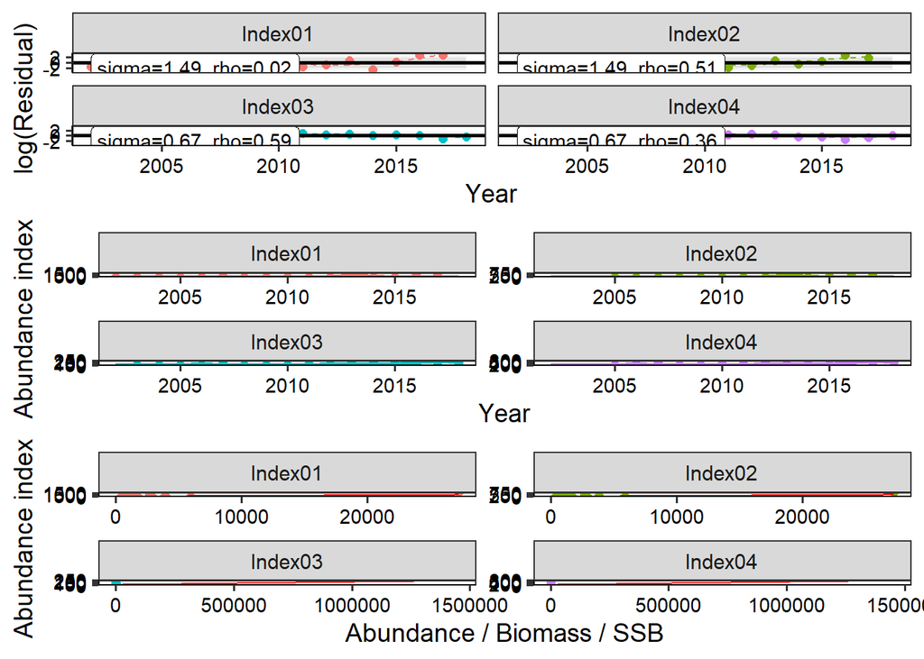

```r
res3.2 <- vpa(dat=dat,
              tf.year = 2015:2017,
              plus.group = TRUE,
              last.catch.zero = TRUE,
              Pope = TRUE,
              tune = TRUE,
              alpha = 1,
              sel.update = TRUE,
              est.method = "ml",
              term.F = "max",
              abund = c("N","N","SSB","SSB"),
              min.age = c(0,0,0,0),
              max.age = c(0,0,6,6),
              use.index = 1:4,
              sigma.constraint = c(1,1,2,2),
              plot = TRUE,
              plot.year = 2002:2018
              )
```

```r
# まずは年齢別漁獲尾数
res3.2$faa[,as.character(2013:2017)]
```

```
##         2013       2014       2015       2016       2017
## 0 0.01337921 0.02917186 0.01067288 0.04476209 0.04262755
## 1 0.17484722 0.05659929 0.05769426 0.07007792 0.10004577
## 2 0.23388453 0.21074076 0.16240693 0.12514650 0.22691972
## 3 0.54687775 0.41392955 0.31685382 0.24236415 0.44135582
## 4 0.23697570 0.27932827 0.21069582 0.15026231 0.28521648
## 5 1.06182919 0.34658295 0.37084980 0.39734994 0.60280070
## 6 1.06182919 0.34658295 0.37084980 0.39734994 0.60280070
```

```r
# 重みの比較
data.frame(Model = c(3.1, 3.2),
           index1 = c(res3.1$sigma[1], res3.2$sigma[1]),
           index2 = c(res3.1$sigma[2], res3.2$sigma[2]),
           index3 = c(res3.1$sigma[3], res3.2$sigma[3]),
           index4 = c(res3.1$sigma[4], res3.2$sigma[4])
           )
```

```
##   Model   index1   index2    index3    index4
## 1   3.1 1.646126 1.256913 0.7207365 0.6209931
## 2   3.2 1.492814 1.492814 0.6722345 0.6722345
```

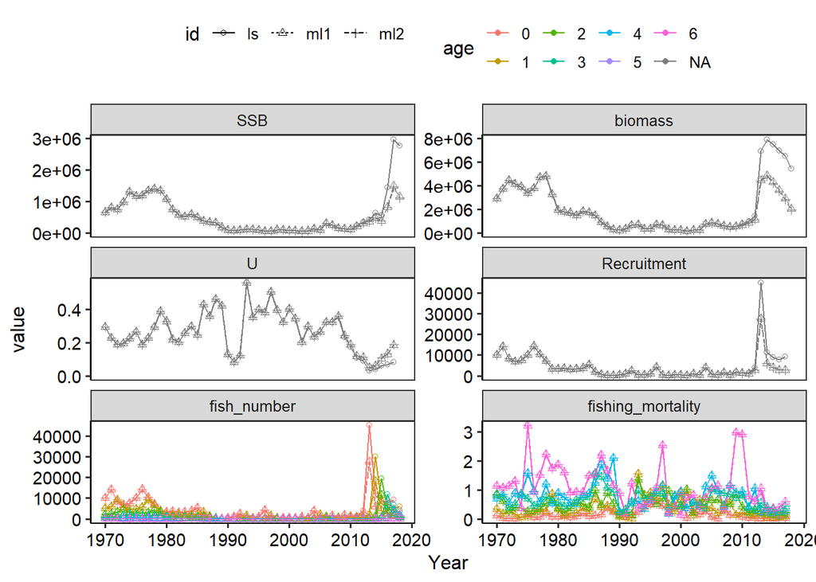

```r
# 資源動態の比較
plot_vpa(list(ls = res2.1, ml1 = res3.1, ml2 = res3.2),
         what.plot = c("SSB", "biomass", "U", "Recruitment",
                       "fish_number", "fishing_mortality"))
```

### モデル診断1: 残差プロット

**patchworkパッケージが必要です!!**

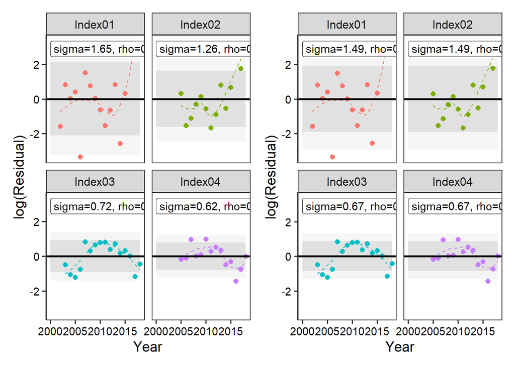

```r
resid3.2 <- plot_residual_vpa(res3.2, plot_year = 2000:2018)

# 残差の時系列プロット
resid3.1$year_resid|resid3.2$year_resid
```

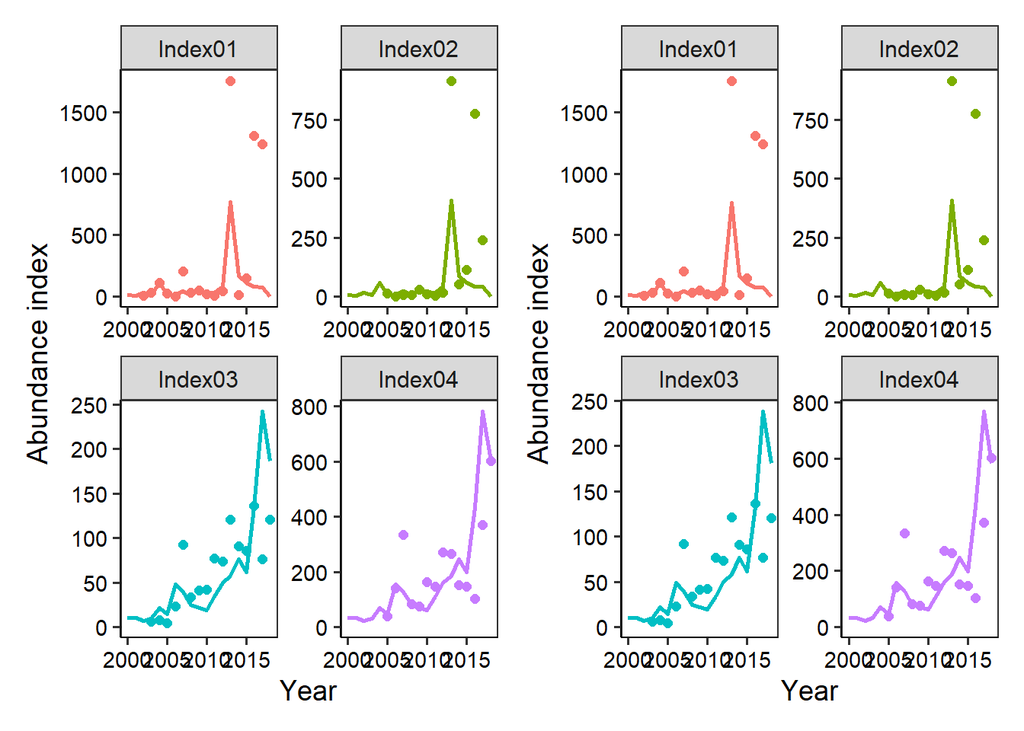

```r
# 資源量とのフィッティング
resid3.1$fitting_Index|resid3.2$fitting_Index
```

### モデル診断2: レトロスペクティブ解析

```r
retro3.2 <- do_retrospective_vpa(res3.2)
```

```
## * value -> value...1
## * value -> value...2
## * value -> value...3
## * value -> value...4
## * value -> value...5
```

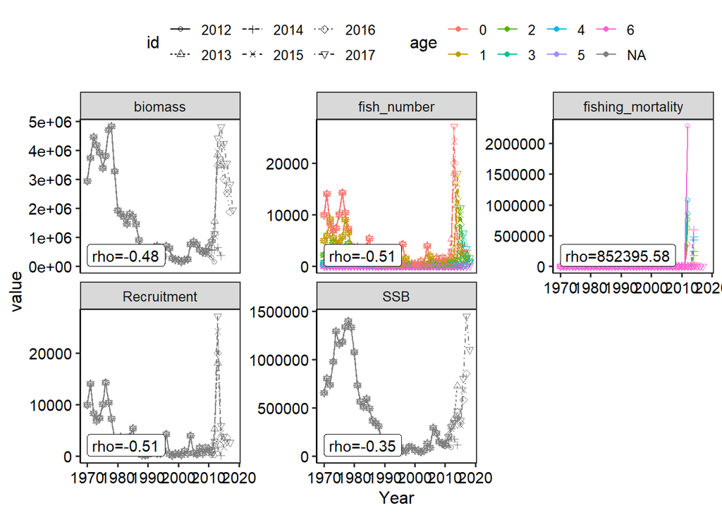

```r
retro3.2$graph
```

- やはりFのレトロの結果が収束していない
- 資源量についても過小推定のレトロバイアスが見られる
- **最小二乗法の方がレトロバイアスが少なく予測能力が高いのか**

### モデル選択

AICという指標を用います。AICが小さい方が予測力のあるモデルと言えます。より小さいAICからの差を取ったものをデルタAICと言い、それをお示しします。

```r
aic2.1 <- 2*res2.1$logLik
aic3.1 <- 2*res3.1$logLik+2*3
aic3.2 <- 2*res3.2$logLik+2*1
data.frame(Model=c(2.1, 3.1, 3.2),
           AIC = c(aic2.1-min(c(aic2.1,aic3.1, aic3.2)),
                   aic3.1-min(c(aic2.1,aic3.1, aic3.2)),
                   aic3.2-min(c(aic2.1,aic3.1, aic3.2))))
```

```
##   Model      AIC
## 1   2.1  0.00000
## 2   3.1 17.83588
## 3   3.2 12.50143
```

- AICでも同様の傾向が見られた
- 指標値の重みは等しくてもいいという結果がデータから示されている

## bの考慮

- 目を凝らして残差プロットを見てみますと、資源量と資源量指数の線形性に疑問を感じ始めました

$$I_t = qB_t^{b}$$
という関係があって、普段は$b=1$です。

したがって、この関数は比例の直線みたいになっています。

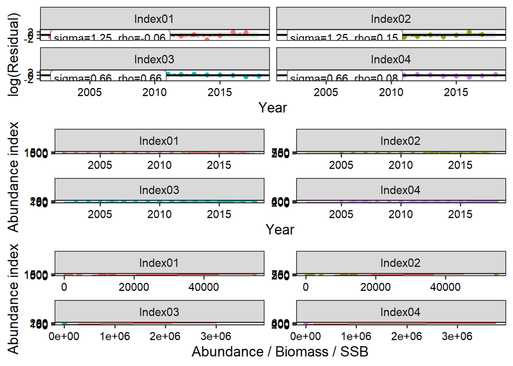

```r
res4.1 <- vpa(dat=dat,
              tf.year = 2015:2017,
              plus.group = TRUE,
              last.catch.zero = TRUE,
              Pope = TRUE,
              tune = TRUE,
              alpha = 1,
              sel.update = TRUE,
              est.method = "ml",
              term.F = "max",
              abund = c("N","N","SSB","SSB"),
              min.age = c(0,0,0,0),
              max.age = c(0,0,6,6),
              use.index = 1:4,
              sigma.constraint = c(1,1,2,2),
              b.est = TRUE, # bを推定するにはここをTRUEにする
              plot = TRUE,
              plot.year = 2002:2018
              )
```

```r
res4.1$b
```

```
## [1] 1.0933420 1.2146768 0.6332071 0.3830410
```

```r
res4.1$faa[,as.character(2013:2017)]
```

```
##          2013       2014        2015       2016        2017
## 0 0.006664792 0.01209421 0.003519552 0.01169498 0.008476137
## 1 0.109550530 0.02769972 0.023313624 0.02248941 0.024768348
## 2 0.165820241 0.12232726 0.075050848 0.04784494 0.065721118
## 3 0.406930730 0.26397593 0.163261238 0.09996187 0.140616098
## 4 0.172527277 0.18410715 0.118704853 0.06867451 0.099953420
## 5 0.846752252 0.23099098 0.216134370 0.19384031 0.221257822
## 6 0.846752252 0.23099098 0.216134370 0.19384031 0.221257822
```

- 親魚の指数のbは1から大きく離れた値が推定されました
- これはすなわち、実際に海にたくさん親魚がいても、その指数（ここではたもすくいと産卵量）は比例せず、ある程度以上の親魚数になると、これらの指標は頭打ちになるということです
  - データからもこういった特性が見えてくるのは面白いですね
  - 良い悪いではなく!
- 年齢別漁獲係数を見てみても、2013年最高齢の極端なFが少し落ち着いた印象を受けます
- bについても重みのパラメータと同様に、必要な分だけ推定するといったことができます
  - 試しに親魚指数だけb推定をするといったことをしてみましょう
  - index2については微妙なので、先程と同様にモデル選択で予測力を確認してみましょう

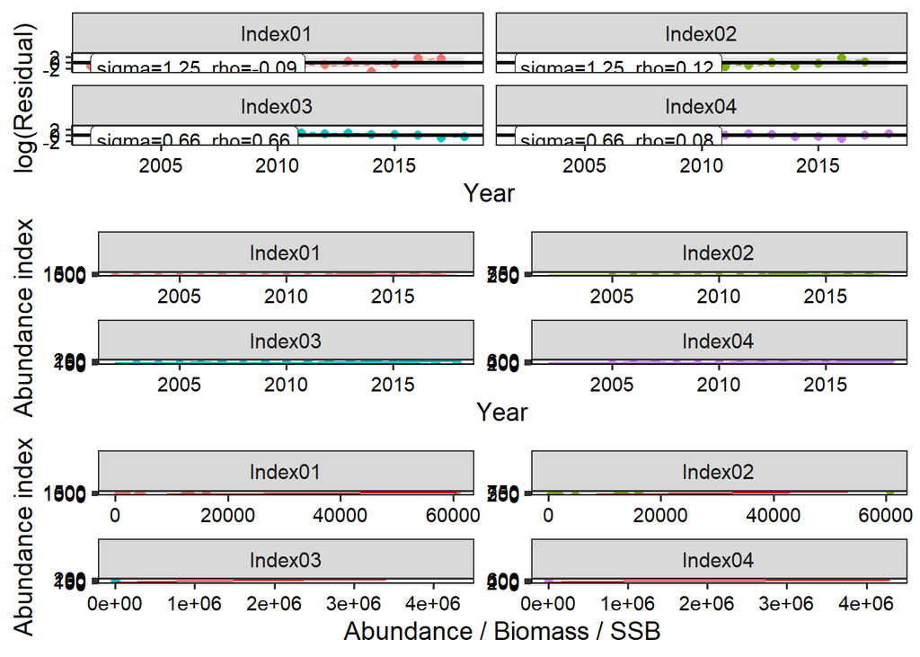

```r
# index1以外bの推定
res4.2 <- vpa(dat=dat,
              tf.year = 2015:2017,
              plus.group = TRUE,
              last.catch.zero = TRUE,
              Pope = TRUE,
              tune = TRUE,
              alpha = 1,
              sel.update = TRUE,
              est.method = "ml",
              term.F = "max",
              abund = c("N","N","SSB","SSB"),
              min.age = c(0,0,0,0),
              max.age = c(0,0,6,6),
              use.index = 1:4,
              sigma.constraint = c(1,1,2,2),
              b.est = TRUE,
              b.fix = c(1,NA,NA,NA),
                      # b推定したい場合はNA
                      # b推定したくない場合は固定したいbの値を入れる
              plot = TRUE,
              plot.year = 2002:2018
              )
```

```r
res4.2$faa[,as.character(2013:2017)]
```

```
##          2013       2014       2015        2016        2017
## 0 0.005984649 0.01064330 0.00303077 0.009858136 0.006982288
## 1 0.101080745 0.02482899 0.02047285 0.019330985 0.020817966
## 2 0.155660316 0.11180614 0.06690605 0.041830111 0.056134804
## 3 0.384934455 0.24418798 0.14726978 0.088236531 0.121421369
## 4 0.162608640 0.17103781 0.10811703 0.061215532 0.087154481
## 5 0.810528467 0.21493651 0.19767569 0.173913210 0.193907071
## 6 0.810528467 0.21493651 0.19767569 0.173913210 0.193907071
```

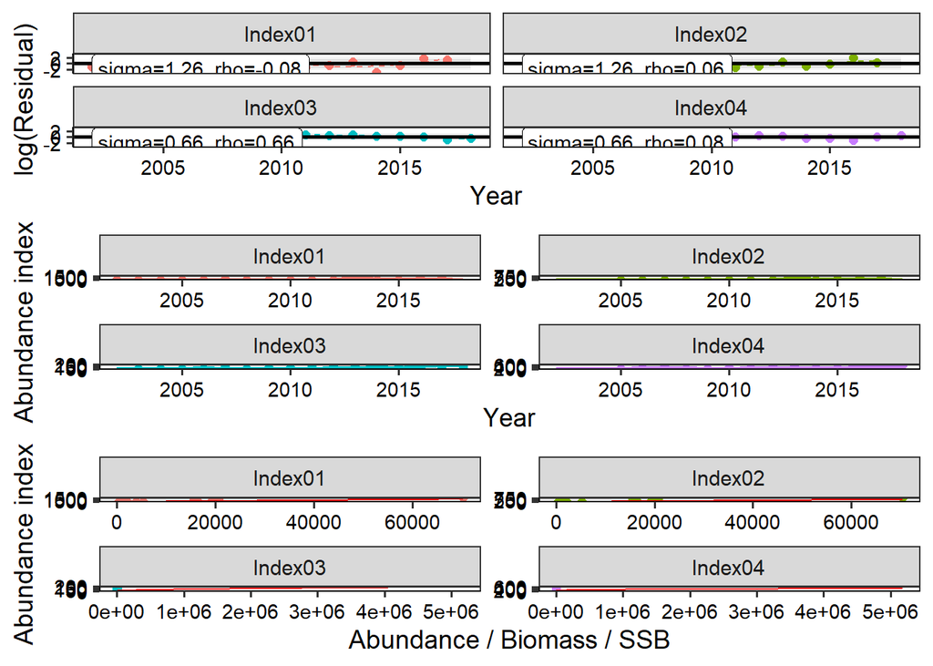

```r
# 親魚指数のみb推定
res4.3 <- vpa(dat=dat,
              tf.year = 2015:2017,
              plus.group = TRUE,
              last.catch.zero = TRUE,
              Pope = TRUE,
              tune = TRUE,
              alpha = 1,
              sel.update = TRUE,
              est.method = "ml",
              term.F = "max",
              abund = c("N","N","SSB","SSB"),
              min.age = c(0,0,0,0),
              max.age = c(0,0,6,6),
              use.index = 1:4,
              sigma.constraint = c(1,1,2,2),
              b.est = TRUE,
              b.fix = c(1,1,NA,NA),
              plot = TRUE,
              plot.year = 2002:2018
              )
```

```r
res4.3$faa[,as.character(2013:2017)]
```

```
##          2013        2014        2015        2016        2017
## 0 0.005159154 0.008950261 0.002482878 0.007872148 0.005426028
## 1 0.090175803 0.021358396 0.017173353 0.015804242 0.016572414
## 2 0.142048900 0.098549241 0.057177858 0.034910343 0.045573234
## 3 0.354967580 0.218579101 0.127709103 0.074531700 0.099923076
## 4 0.149194692 0.153948727 0.094880651 0.052325431 0.072584567
## 5 0.759962661 0.193871025 0.174392027 0.149832204 0.162510250
## 6 0.759962661 0.193871025 0.174392027 0.149832204 0.162510250
```

```r
# bの値の比較
data.frame(Model = c(4.1, 4.2, 4.3),
           index1 = c(res4.1$b[1], res4.2$b[1], res4.3$b[1]),
           index2 = c(res4.1$b[2], res4.2$b[2], res4.3$b[2]),
           index3 = c(res4.1$b[3], res4.2$b[3], res4.3$b[3]),
           index4 = c(res4.1$b[4], res4.2$b[4], res4.3$b[4])
           )
```

```
##   Model   index1   index2    index3    index4
## 1   4.1 1.093342 1.214677 0.6332071 0.3830410
## 2   4.2 1.000000 1.171236 0.6071658 0.3651358
## 3   4.3 1.000000 1.000000 0.5756483 0.3433965
```

```r
aic4.1 <- 2*res4.1$logLik
aic4.2 <- 2*res4.2$logLik-2*1
aic4.3 <- 2*res4.3$logLik-2*2
data.frame(Model=c(4.1, 4.2, 4.3),
           AIC = c(aic4.1-min(c(aic4.1,aic4.2, aic4.3)),
                   aic4.2-min(c(aic4.1,aic4.2, aic4.3)),
                   aic4.3-min(c(aic4.1,aic4.2, aic4.3))))
```

```
##   Model      AIC
## 1   4.1 4.494164
## 2   4.2 2.391512
## 3   4.3 0.000000
```

**bは最小限、親魚の指数に対してのみ推定したほうがいいみたいですね**

**モデル診断も忘れてはいけません!!**

### モデル診断1: 残差プロット

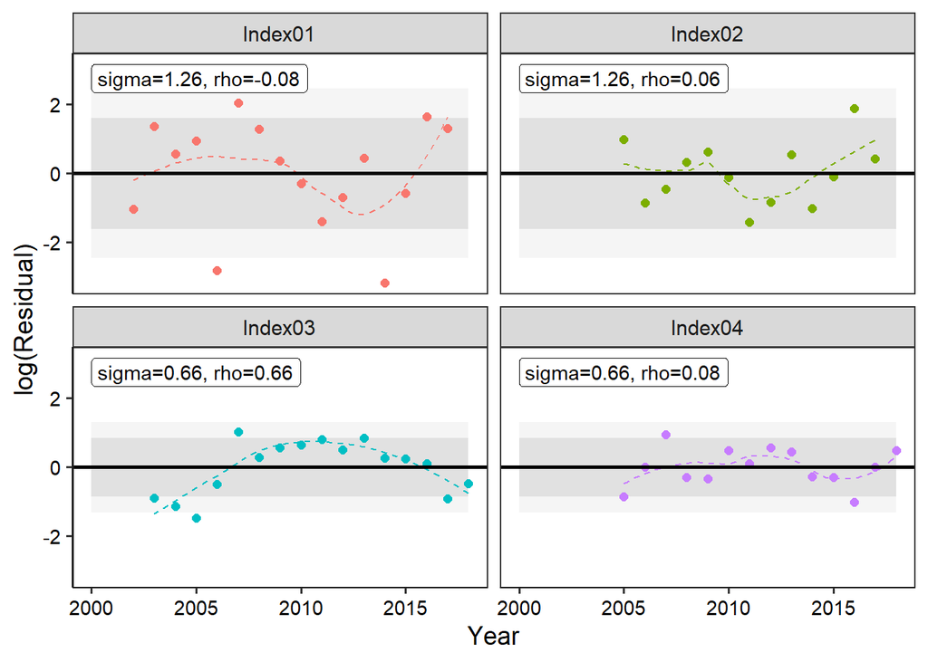

```r
resid4.3 <- plot_residual_vpa(res4.3, plot_year = 2000:2018)

# 残差の時系列プロット
resid4.3$year_resid
```

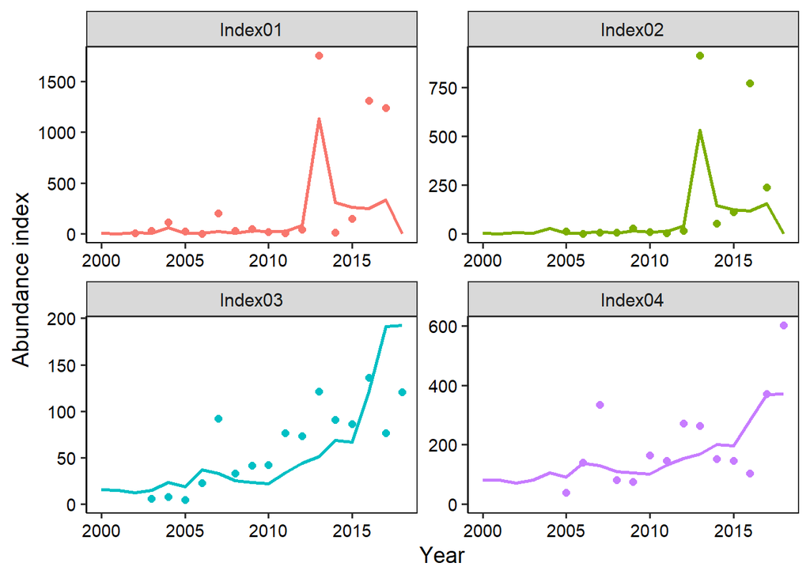

```r
# 資源量とのフィッティング
resid4.3$fitting_Index
```

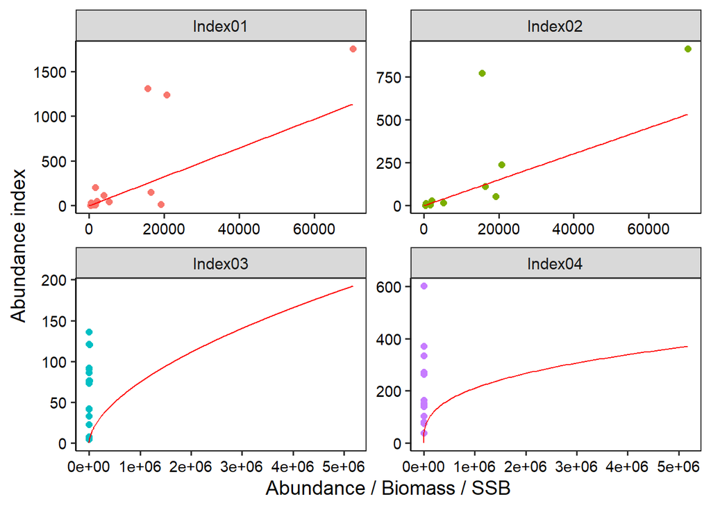

```r
# 資源量と資源量指数の関係
resid4.3$abund_Index
```

### モデル診断2: レトロスペクティブ解析

```r
retro4.3 <- do_retrospective_vpa(res4.3)
```

```
## * value -> value...1
## * value -> value...2
## * value -> value...3
## * value -> value...4
## * value -> value...5
```

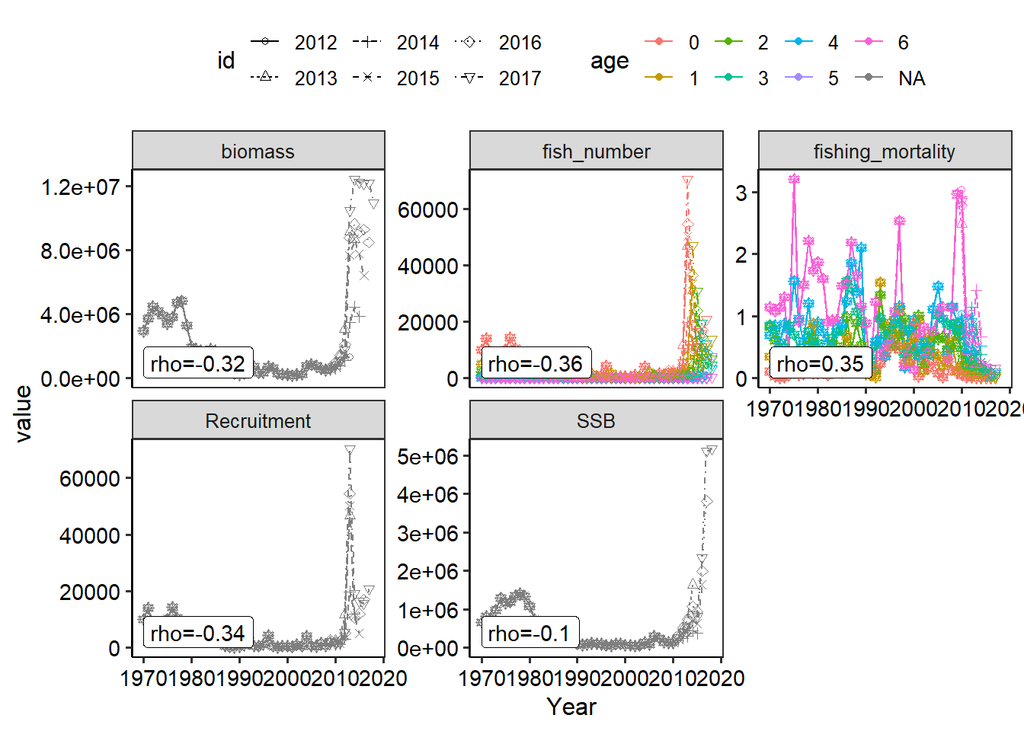

```r
retro4.3$graph
```

- まだバイオマスに過小推定のレトロバイアスが見られる
- 前のモデルよりMohn’s rhoは小さくなってきている

### 観測誤差を等しくした場合

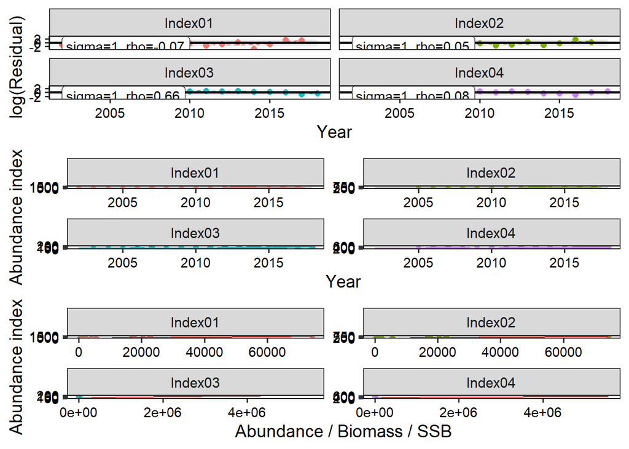

```r
res4.4 <- vpa(dat=dat,
              tf.year = 2015:2017,
              plus.group = TRUE,
              last.catch.zero = TRUE,
              Pope = TRUE,
              tune = TRUE,
              alpha = 1,
              sel.update = TRUE,
              est.method = "ml",
              term.F = "max",
              abund = c("N","N","SSB","SSB"),
              min.age = c(0,0,0,0),
              max.age = c(0,0,6,6),
              use.index = 1:4,
              sigma.constraint = c(1,1,1,1), # 最小二乗法の意味です
              b.est = TRUE,
              b.fix = c(1,1,NA,NA),
              plot = TRUE,
              plot.year = 2002:2018
              )
```

```r
res4.4$faa[,as.character(2013:2017)]
```

```
##         2013        2014        2015        2016        2017
## 0 0.00488529 0.008404904 0.002311551 0.007267566 0.004965103
## 1 0.08639399 0.020210292 0.016114032 0.014704367 0.015285206
## 2 0.13718217 0.094025796 0.053987767 0.032703638 0.042309664
## 3 0.34410988 0.209662022 0.121179480 0.070106792 0.093194052
## 4 0.14436321 0.147951814 0.090390644 0.049413521 0.067967303
## 5 0.74127764 0.186458712 0.166440170 0.141864182 0.152496043
## 6 0.74127764 0.186458712 0.166440170 0.141864182 0.152496043
```

### AIC

```r
aic4.4 <- 2*res4.4$logLik-2*3
data.frame(Model=c(4.1, 4.2, 4.3, 4.4),
           AIC = c(aic4.1-min(c(aic4.1,aic4.2, aic4.3, aic4.4)),
                   aic4.2-min(c(aic4.1,aic4.2, aic4.3, aic4.4)),
                   aic4.3-min(c(aic4.1,aic4.2, aic4.3, aic4.4)),
                   aic4.4-min(c(aic4.1,aic4.2, aic4.3, aic4.4))))
```

```
##   Model      AIC
## 1   4.1 17.77290
## 2   4.2 15.67025
## 3   4.3 13.27873
## 4   4.4  0.00000
```

最尤法でデータごとの重み（観測誤差sigma）を推定するより、重みは等しいと考えた方がいいみたいです

## 全F推定法

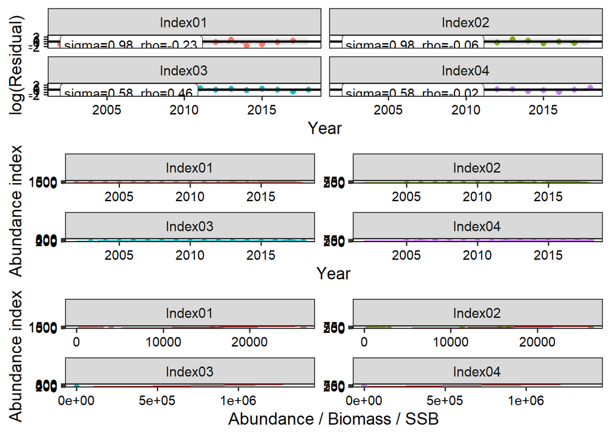

```r
res5.1 <- vpa(dat,
              tf.year = 2015:2017,
            tune = TRUE,
            term.F = "all",
            alpha = 1,
            abund = c("N","N","SSB","SSB"),
            min.age = c(0,0,0,0),
            max.age = c(0,0,6,6),
            est.method="ml", #重み推定（最尤法）
            b.est = TRUE, #b推定
            sel.def="max",
            #b.fix = c(1,1,NA,NA),
            last.catch.zero=TRUE,
            fc.year=2016:2018,
            plot = TRUE,
            plot.year = 2002:2018,
            p.init=res4.3$faa[,"2017"][-7],
            use.index =1:4,
            sigma.constraint = c(1,1,2,2) #北上期と秋季のsigmaを一定
)
```

```r
res5.1$b
```

```
## [1] 1.3595329 1.3655585 1.5121782 0.9777056
```

```r
res5.1$faa[,as.character(2013:2017)]
```

```
##         2013       2014        2015       2016         2017
## 0 0.02336739 0.06180417 0.003626831 0.00468078  0.006758206
## 1 0.23473893 0.10157924 0.128676840 0.02318417  0.009805086
## 2 0.28376790 0.30533973 0.321909437 0.31743597  0.067846322
## 3 0.64226932 0.54832753 0.533345385 0.62271538 16.172214955
## 4 0.28209990 0.35898386 0.315539805 0.30611728  1.522025773
## 5 1.19558458 0.44157477 0.536604811 0.73123664 16.601352492
## 6 1.19558458 0.44157477 0.536604811 0.73123664 16.601352492
```

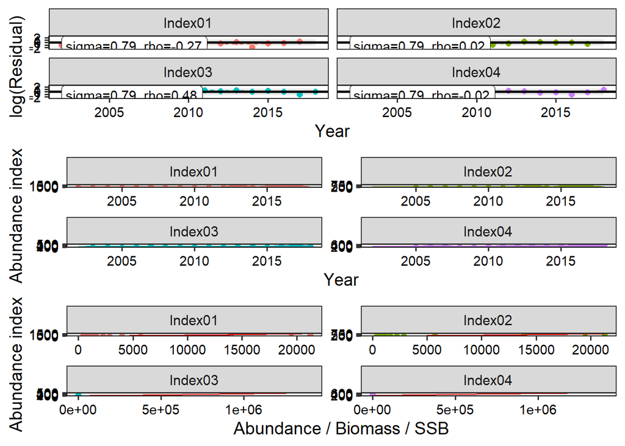

```r
res5.2 <- vpa(dat,
              tf.year = 2015:2017,
            tune = TRUE,
            term.F = "all",
            alpha = 1,
            abund = c("N","N","SSB","SSB"),
            min.age = c(0,0,0,0),
            max.age = c(0,0,6,6),
            est.method="ls",
            b.est = TRUE, #b推定
            sel.def="max",
            #b.fix = c(1,1,NA,NA),
            last.catch.zero=TRUE,
            fc.year=2016:2018,
            plot = TRUE,
            plot.year = 2002:2018,
            p.init = c(0.1,0.1,0.1,0.5,1,1),
            use.index =1:4
)
```

```r
res5.2$b
```

```
## [1] 1.4508903 1.4565430 1.2934593 0.8064219
```

```r
res5.2$faa[,as.character(2013:2017)]
```

```
##         2013       2014        2015        2016         2017
## 0 0.01876389 0.06180416 0.007159309 0.005769047 8.096616e-03
## 1 0.23473894 0.08054069 0.128676815 0.046377818 1.210521e-02
## 2 0.28376790 0.30533974 0.243234863 0.317435895 1.424375e-01
## 3 0.64226932 0.54832754 0.533345404 0.409622914 1.480253e+01
## 4 0.28209991 0.35898387 0.315539813 0.306117300 6.125895e-01
## 5 1.19558458 0.44157478 0.536604823 0.731236670 5.798578e+02
## 6 1.19558458 0.44157478 0.536604823 0.731236670 5.798578e+02
```

## VPA計算けっかまとめ

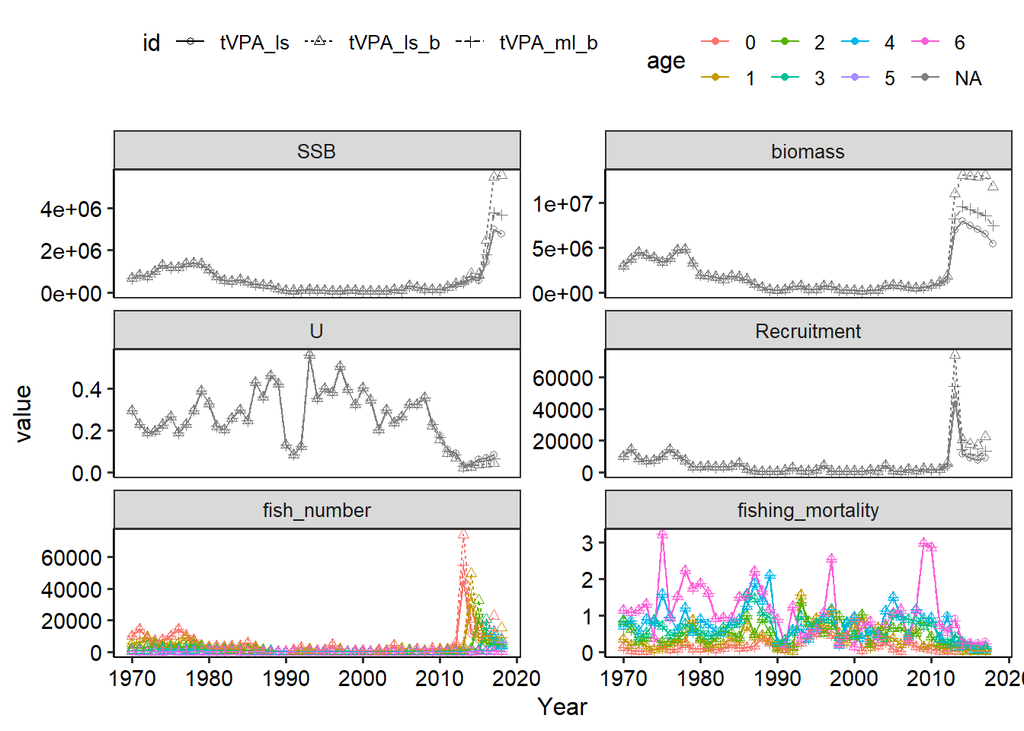

```r
plot_vpa(list(tVPA_ls = res2.1, tVPA_ls_b = res4.4, tVPA_ml_b = res4.1),
         what.plot = c("SSB", "biomass", "U", "Recruitment",
                       "fish_number", "fishing_mortality"))
```